# EI-EP08-respuesta-equipo-2

2025-12-03

```r
library(ggplot2)
library(DT) #Para hacer tablas
library(plotly)
library(dplyr)
library(tibble)
library(purrr)
library(rsample)
library(glue)
library(tidyr)
library(ggpubr)

datos <- read.csv("EP08 Datos CASEN 2017.csv")
```

- y27a - cuenta de ahorro
- e8 - tipo de institución
- region - región

Se quiere estudiar si existe una relación entre el lugar donde se lleva a cabo la educación superior y el hecho de tener una cuenta de ahorro en las regiones de Tarapacá y Metropolitana. Lo anterior, con el fin de comprender si se puede extraer información sobre la educación financiera de los estudiantes en pos de realizar una mejora de ser necesario.

Para ello se estudiará la frecuencia de personas que no tiene una cuenta de ahorro que ha realizado su educación superior, y ver si es la misma en la región de Tarapacá y la región Metropolitana.

Para lo anterior, se extraen los datos necesarios para llevar a cabo un análisis. En este caso:

```r
regiones_filtradas <- datos %>%
  filter(region %in% c(
    "Región Metropolitana de Santiago",
    "Región de Tarapacá"
  ))

datosRelevantes <- data.frame(
  id_vivienda = regiones_filtradas$id.vivienda,
  y27a = regiones_filtradas$y27a,
  e8 = regiones_filtradas$e8,
  region = regiones_filtradas$region
)

datos_filtrados <- datosRelevantes %>%
  filter(!is.na(e8), e8 != "N/A" | e8 != "No sabe/no responde")
```

Primero, extraeremos una muestra aleatoria de entre 100 y 150 muestras para el estudio según lo indicado en el enunciado. La semilla elegida corresponderá a los últimos tres números del rut de uno de los integrantes.

```r
set.seed(234)

muestra <- datos_filtrados[sample(nrow(datos_filtrados), 125, replace = FALSE),]
```

Para responder a la pregunta se hará una prueba de permutaciones de Monte Carlo. Enunciamos nuestras hipotesis y nuestro parametro a estudiar:

Queremos ver si la frecuencia en la que la gente que haya tenido estudios superiores que tenga no tenga cuenta de ahorro es la misma para las poblaciones de la region metropolitana y la region de tarapaca, por lo que estaremos infiriendo sobre las medias de estas para compararlas.

$H_0$ : Las frecuencias de seleccionar una persona con estudios superiores que no tenga cuenta de ahorro es similar para la región Metropolitana que en la de Tarapacá.

Matemáticamente: $\mu_M = \mu_T$

$H_a$ : Las frecuencias de seleccionar una persona con estudios superiores que no tenga cuenta de ahorro difiere para la región Metropolitana que en la de Tarapacá.

Matemáticamente: $\mu_M \neq \mu_T$

Luego creamos las permutaciones sin reposicion, en este caso usaremos 5999 remuestras.

```r
muestra_metropolitana <- muestra %>%
  filter(region == "Región Metropolitana de Santiago")

muestra_tarapaca <- muestra %>%
  filter(region == "Región de Tarapacá")

y27a_metropolitana <- muestra_metropolitana$y27a
y27a_tarapaca <- muestra_tarapaca$y27a

Muestra <- factor(c(rep("Metropolitana", length(y27a_metropolitana)), rep("Tarapacá", length(y27a_tarapaca))))

datos_largos <- tibble(Muestra, y27a = c(y27a_metropolitana, y27a_tarapaca))

datos_largos <- datos_largos |>
  mutate(
    y27a_bin = case_when(
      y27a == "Si" ~ 1,
      y27a == "No" ~ 0,
      y27a == "No sabe/No responde" ~ 0,
      TRUE ~ NA_real_
    )
  ) |>
  filter(!is.na(y27a_bin))

R = 5999
remuestras <- permutations(datos_largos, permute = y27a_bin, times = R, apparent=TRUE)

dif_dos_medias <- function(remuestra, ...) {
  analysis(remuestra) |>
    group_by(Muestra) |>
    summarise(m = mean(y27a_bin)) |>
    summarise(m[1] - m[2]) |>
    pull()
}

dist_perm <- remuestras |> mutate(dif_m = map(splits, dif_dos_medias)) |> unnest( dif_m)

dif_obs <- dist_perm |> filter(id == "Apparent") |> pull(dif_m)

n_extremos <- dist_perm |> filter(abs(dif_m) >= abs(dif_obs)) |> summarise (n = n ())
p_valor <- n_extremos / (R + 1)
p_valor <- p_valor$n
cat("p-value =", p_valor, "\n")
```

```
## p-value = 0.6896667
```

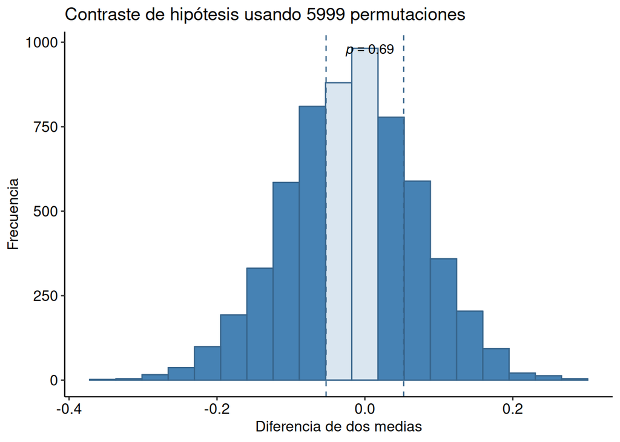

```r
titulo <- paste("Contraste de hipótesis usando", R, "permutaciones")

y27a <- if_else(
  p_valor < 0.001,
  glue("italic(p) ~ '<' ~ 0.001"),
  glue("italic(p) == {sprintf('%.3f', p_valor)}")
)

ancho_barra <- diff(range(dist_perm[["dif_m"]])) /
  nclass.scott(dist_perm[["dif_m"]])

ancho_barra_ajustado <- abs(dif_obs) /
  max(1, round(abs(dif_obs) / ancho_barra))

dist_perm_pl <- dist_perm |>
  mutate(
    extremo = factor(if_else(abs(dif_m) >= abs(dif_obs), 1, 0))
  ) |>
  ggplot(aes(x = dif_m)) +
  geom_histogram(
    aes(alpha = extremo),
    #boundary = 0,
    #binwidth = ancho_barra_ajustado,
    bins = 19,
    color = "steelblue4",
    fill = "steelblue"
  ) +
  labs(
    title = titulo,
    x = "Diferencia de dos medias",
    y = "Frecuencia"
  ) +
  geom_vline(
    xintercept = c(-dif_obs, dif_obs),
    colour = "steelblue4",
    linetype = "dashed"
  ) +
  annotate(
    "text",
    x = dif_obs,
    y = Inf,
    hjust = 1.2,
    vjust = 2,
    label = y27a,
    parse = TRUE
  ) +
  scale_alpha_manual(values = c("0" = 0.2, "1" = 1), guide = NULL) +
  theme(plot.title = element_text(hjust = 0.5)) +
  theme_pubr()

print(dist_perm_pl)
```